# k-Nearest Neighbors Analysis with Biometric Data

June 15, 2016

## Overview of the Model and the Case Presented

## What is kNN?

kNN is a relatively simple machine learning algorithm that is used for classification tasks.

It is often referred to as a "lazy learner" because it does not produce a true mathematical model. (i.e. it doesn't fit the traditional definition of 'learning')

## How does it work?

- Take a dataset for which the correct classifications of all observations are known
- Plot all of the observations as points on a graph
- Plot an observation for which the correct classification is not known
- Calculate the distance between it and all the other n on the graph
- Determine the *k* nearest observations to that point
- Whatever class the majority of those observations belong to, assign that class to the unknown observation

### k-Nearest Neighbors Illustration

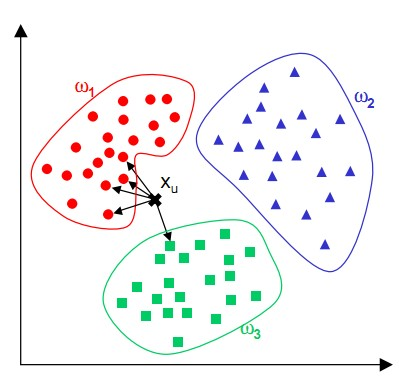

In this diagram, *k* has been set as 5. We can see that the 5 nearest 'neighbors' to **X** have been identified. Of those 5 observations, 4 of them belong to the group w1, and therefore **X** is classified as a member of w1 as well.

## What is kNN used for?

kNN has been used in many different cases, including

- Predicting what products a person might like
- Identifying cells in tumors as cancerous or benign
- Optical character recognition and facial recognition
- Identifying patterns in DNA (disease prediction, protein identification)

## Strengths of kNN

- It's relatively easy to implement
- It's surprisingly effective
- Training phase is very fast
- Data does not have to follow a particular type of distribution
- The math involved is simple and easy to understand

## Weaknesses of kNN

- Choosing the correct *k* is very important, yet can be tricky
- A true model is not produced, and therefore interpretation of results can be very difficult
- Missing features are not handled well
- Non-numeric data needs further processing, and can be problematic
- The algorithm needs to be run every time new classifications are made, which can be extremely computationally expensive

## Using biometric data to identify users of mobile technology

We will be attempting to identify inviduals based on their individual walking patterns.

Pierluigi Casale at the Computer Vision Center in Barcelona Spain Created the dataset.

The data was originally used in the research paper 'Personalization and User Verification in Wearable Systems Using Biometric Walking Patterns' originally published in Personal and Ubiquitous Computing in 2012.

## The dataset

The data is actually in 22 files which collectively contain nearly 150,000 observations, each file consisting of a set of observations from one invdividual

The observations were taken with an accelerometer in an Android phone that was placed in the users' shirt pocket.

Each subject walked across a specific walking trail in the wilderness in Spain.

Each observation represents one step, and contains 4 variables - the time elapsed during the step, and acceleration in the x, y, and z directions of 3-dimensional space.

The datasets were downloaded from the [University of California Irvine Machine Learning Repository](https://archive.ics.uci.edu/ml/datasets/User+Identification+From+Walking+Activity)

## Possible uses for the model

Given a sample of observations of a set of individuals, a piece of mobile or wearable technology could identify which person in the dataset was carrying or using it. This could be used to

- Identify whether the person carrying a mobile phone was its actual user
- Create an automated check-out system where users of specific tools or technology at a company could be identified simply by walking away with, or using the technology
- Report back on how specific users were using mobile technology, and whether or not they were using it as intended or within permitted usage rules
- Automate loading of preferences or capabilities set for a list of users

## Performing the Analysis in R

## Different stages in our analysis

1. Data Exploration / Data Preparation
2. Training the Model
3. Evaluating / Improving the Model
4. Exploring / Interpreting Results

## Data Exploration and Preparation

The first step in R will be to set our working directory, then load one of the datasets into an R data frame and take a look at the first few observations.

```r
setwd("~/Documents/KNN_Presentation")
walkData <- read.csv("1.csv", header = FALSE)

head(walkData)
```

```
##         V1       V2      V3      V4
## 1 0.000000  0.69464 3.17350  7.5048
## 2 0.030639  0.14982 3.48680  9.2755
## 3 0.069763 -0.29965 1.94770  9.1120
## 4 0.099823 -1.68890 1.41650 10.1200
## 5 0.129820 -2.17930 0.95342 10.9240
## 6 0.159790 -2.30180 0.23155 10.6510
```

A greater or lesser number of rows can be viewed with the `head()` function by setting the `n` parameter:

```r
head(walkData, n=10)
```

```
##          V1       V2      V3      V4
## 1  0.000000  0.69464 3.17350  7.5048
## 2  0.030639  0.14982 3.48680  9.2755
## 3  0.069763 -0.29965 1.94770  9.1120
## 4  0.099823 -1.68890 1.41650 10.1200
## 5  0.129820 -2.17930 0.95342 10.9240
## 6  0.159790 -2.30180 0.23155 10.6510
## 7  0.189820 -1.41650 1.18500 11.0730
## 8  0.220400 -0.27241 2.22010 11.9860
## 9  0.249760 -0.61292 2.22010 11.9860
## 10 0.279720  1.33480 4.24950 11.4140
```

Note that we only see the four variables in the data - there is no column containing a classification

In this step a row is added which contains the classification for this dataset. Since the participants in the study remain anonymous we will simply identify them by the integer name of the data file their data resides in.

```r
walkData$class <- as.factor(1)

head(walkData)
```

```
##         V1       V2      V3      V4 class
## 1 0.000000  0.69464 3.17350  7.5048     1
## 2 0.030639  0.14982 3.48680  9.2755     1
## 3 0.069763 -0.29965 1.94770  9.1120     1
## 4 0.099823 -1.68890 1.41650 10.1200     1
## 5 0.129820 -2.17930 0.95342 10.9240     1
## 6 0.159790 -2.30180 0.23155 10.6510     1
```

Next a `for` loop is used to open each of the remaining 21 datasets, load them into a temporary data frame, add a new column with the classification value as in the previous step, and then bind the rows in the new data frame to the existing `walkData` data frame.

```r
for (i in 2:22) {
  fileName <- paste(toString(i), ".csv", sep = "")
  tempFrame <- read.csv(fileName, header = FALSE)
  tempFrame$class <- as.factor(i)
  walkData <- rbind(walkData, tempFrame)
}
```

Then save the raw data frame as a `.csv` file

```r
write.csv(walkData, 'walk_data.csv', row.names = FALSE)
```

Once again we'll use the `head()` function to view our data, as well as the `tail()` and `str()` functions to see if our data frame is looking the way we expect it to.

```r
head(walkData, n=3)
```

```
##         V1       V2     V3     V4 class
## 1 0.000000  0.69464 3.1735 7.5048     1
## 2 0.030639  0.14982 3.4868 9.2755     1
## 3 0.069763 -0.29965 1.9477 9.1120     1
```

```r
tail(walkData, n=3)
```

```
##            V1       V2     V3     V4 class
## 149330 305.24 -0.76274 5.8976 8.1586    22
## 149331 305.27 -1.07600 5.7069 7.1643    22
## 149332 305.30 -1.07600 5.7478 7.8862    22
```

```r
str(walkData)
```

```
## 'data.frame':    149332 obs. of  5 variables:
##  $ V1   : num  0 0.0306 0.0698 0.0998 0.1298 ...
##  $ V2   : num  0.695 0.15 -0.3 -1.689 -2.179 ...
##  $ V3   : num  3.174 3.487 1.948 1.417 0.953 ...
##  $ V4   : num  7.5 9.28 9.11 10.12 10.92 ...
##  $ class: Factor w/ 22 levels "1","2","3","4",..: 1 1 1 1 1 1 1 1 1 1 ...
```

We can see that our column names are mostly meaningless. The `colnames()` function can be used to easily change the column names in an R data frame.

```r
colnames(walkData) <- c("step_time", "acc_x", "acc_y", "acc_z", "class")
```

Now the `summary()` function will be used to give display a statistical summary of the variables in the dataset.

```r
summary(walkData)
```

```
##    step_time          acc_x               acc_y
##  Min.   :  0.00   Min.   :-19.57200   Min.   :-10.924
##  1st Qu.: 56.78   1st Qu.: -3.14630   1st Qu.:  7.164
##  Median :127.37   Median : -1.30760   Median :  8.853
##  Mean   :185.56   Mean   : -1.65533   Mean   :  8.769
##  3rd Qu.:273.68   3rd Qu.: -0.04086   3rd Qu.: 10.338
##  Max.   :676.68   Max.   : 19.31400   Max.   : 19.572
##
##      acc_z               class
##  Min.   :-14.98200   17     :21991
##  1st Qu.: -1.22580   18     :20758
##  Median : -0.08172   20     :16949
##  Mean   :  0.55558   14     :12027
##  3rd Qu.:  1.53910   22     : 9698
##  Max.   : 19.34100   9      : 7988
##                      (Other):59921
```

Let's look at what proportion of the observations is represented by each class in the dataset.

```r
class_proportions <- round(prop.table(table(walkData$class)) * 100,
                           digits = 1)
class_proportions
```

```
##
##    1    2    3    4    5    6    7    8    9   10   11   12   13   14   15
##  3.4  2.6  0.8  4.7  0.8  3.3  2.5  2.3  5.3  2.1  3.8  3.2  4.5  8.1  2.4
##   16   17   18   19   20   21   22
##  1.2 14.7 13.9  0.6 11.3  2.1  6.5
```

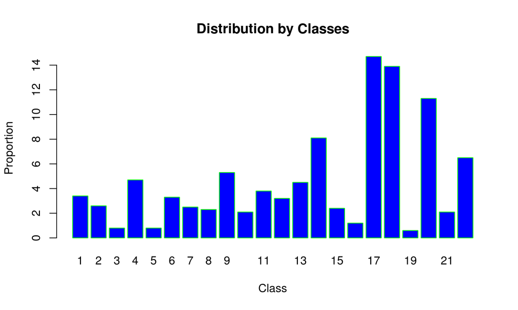

```r
barplot(class_proportions,
     col = "blue",
     border = "green",
     main = "Distribution by Classes",
     ylab = "Proportion",
     xlab = "Class")
```

The `barplot()` function on the previous slide results in this visualization. The obvious disparity in the proportion of observations represented by each class could have a great impact on how *k* is chosen, and could impact model accuracy.

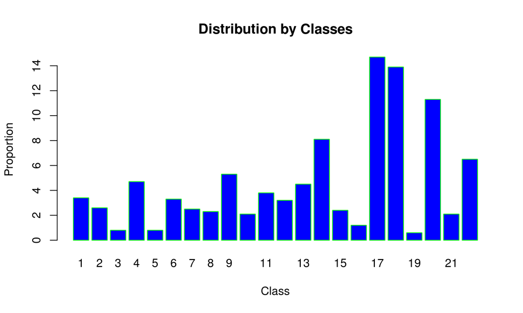

For kNN to work properly all the variables need to be transformed to the same scale. First of all we'll write a function that scales all 4 independent variables so that their values fall between 0 and 1.

```r
normalize <- function(x) {
  return ((x - min(x)) / (max(x) - min(x)))
}

walkData_N <- as.data.frame(lapply(walkData[1:4], normalize))
summary(walkData_N)
```

```
##    step_time           acc_x            acc_y            acc_z
##  Min.   :0.00000   Min.   :0.0000   Min.   :0.0000   Min.   :0.0000
##  1st Qu.:0.08391   1st Qu.:0.4224   1st Qu.:0.5931   1st Qu.:0.4008
##  Median :0.18823   Median :0.4697   Median :0.6485   Median :0.4341
##  Mean   :0.27422   Mean   :0.4607   Mean   :0.6458   Mean   :0.4527
##  3rd Qu.:0.40445   3rd Qu.:0.5023   3rd Qu.:0.6972   3rd Qu.:0.4813
##  Max.   :1.00000   Max.   :1.0000   Max.   :1.0000   Max.   :1.0000
```